# Análisis de Negocio sector Retail

## Análisis de Negocio

El desarrollo de este Notebook se centra en analizar el comportamiento de un negocio digital en línea que conecta pequeñas empresas de Colombia, a través del uso de un sólo canal y un sólo contrato. Los comerciantes pueden vender sus productos a través de una tienda en línea y enviarlo directamente a los clientes a través de múltiples empresas logísticas aliadas. Además, luego de que un cliente compra el producto en la tienda el línea, el vendedor recibe una notificación y permite finalizar la transacción. Por otra parte, una vez que el cliente recibe el producto, o la fecha estimada de entrega se vence, el cliente recibe una encuesta de satisfacción por correo electrónico donde puede evaluar la experiencia de compra y agregar algunos comentarios.

### Objetivo:

EL onjetivo principal es identificar las principales características sobre envíos, precios, valor de fletes y múltiples variables adicionales con el fin de estudiar el comportamiento que presentan las ventas a través del negocio digital. De manera específica lograremos:

1. Preparar el conjunto de datos y validar su calidad para emplear en el análisis propuesto.
2. Identificar las principales características en los datos a través del uso de estadística univariada y estadística bivariada.
3. Responder preguntas acerca del comportamiento de algunas variables del negocio.
4. Transformar la información proporcionada por el conjunto de datos en representaciones visuales a través de la visualización de datos en Python con el objetivo de analizar la información y comunicar de manera más efectivas las conclusiones obtenidas.

### Conocimientos aplicados

1. Carga de archivos mediante Pandas.
2. Preparación y validación de la calidad del conjunto de datos a emplear.
3. Análisis exploratorio de datos.
4. Visualización de datos con Python.

## 1. Importación de librerías y archivos

En las siguientes líneas de código vamos a importar las librerías a utilizar en el análisis de las características del negocio, así como los archivos que contienen el conjunto de datos.

```python
#Importamos las liberías necesarias para realizar el análisis de interés.
import pandas as pd #librería para manejo de datos.
from datetime import date #librería para manejar tipo de datos datetime.
import numpy as np #librería para cálculos matemáticos
#nos permite analizar gráficos a través del mouse y redimencionarlas a conveniencia
import plotly.express as px
import random

#cargamos el conjunto de datos a emplear.
data_ordenes=pd.read_csv('Ordenes_productos_C1_M2.3.csv', sep=';')
data_ordenes.head()
```

|  | orden_id | order_item_id | producto_id | vendedor_id | fecha_envio_limite | precio | valor_flete | codigo_postal_vendedor | ciudad_vendedor | departamento_vendedor | nombre_categoria_producto | longitud_nombre_producto | longitud_descripcion_producto | cantidad_fotos_producto | peso_g_producto | longitud_cm_producto | altura_cm_producto | ancho_cm_producto |
| --- | --- | --- | --- | --- | --- | --- | --- | --- | --- | --- | --- | --- | --- | --- | --- | --- | --- | --- |
| 0 | 107500PO59A | A | PO59 | VE5389 | 7/04/2018 18:12 | 271.86 | 30.72 | 52435 | Mallama | Nariño | Productos ecoamigables | 6.0 | 7.0 | 27.0 | 2486.0 | 17.0 | 11.0 | 14.0 |
| 1 | 37493PS22B | B | PS22 | VE1558 | 20/10/2017 9:07 | 115.73 | 4.68 | 52203 | Colon | Nariño | Carnicería | 10.0 | 31.0 | 20.0 | 256.0 | 43.0 | 2.0 | 21.0 |
| 2 | 28050PK20B | B | PK20 | VE9159 | 17/08/2017 8:15 | 432.99 | 82.70 | 66001 | Pereira | Risaralda | Deportes | 25.0 | 5.0 | 4.0 | 5270.0 | 9.0 | 27.0 | 29.0 |
| 3 | 52187PA10A | A | PA10 | VE3159 | 23/09/2017 23:27 | 108.38 | 35.39 | 52435 | Mallama | Nariño | Electrodomésticos | 10.0 | 1.0 | 6.0 | 734.0 | 46.0 | 48.0 | 22.0 |
| 4 | 84639PR12A | A | PR12 | VE5090 | 7/01/2018 11:50 | 51.50 | 11.10 | 73001 | Ibague | Tolima | Frutas y verduras | 23.0 | 16.0 | 35.0 | 884.0 | 45.0 | 26.0 | 18.0 |

```python
#validamos en tamaño de nuestro conjunto de datos.
data_ordenes.shape
```

```
(10134, 18)
```

**El conjunto de datos:** observamos que el conjunto de datos posee un total de 10134 registros y 18 atributos.

## 2. Validación de la calidad de los datos

Una vez hallamos importados las librerías y el archivo a emplear para el análisis, validaremos cuál es la calidad que presentan dichos datos con el fin de **identificar si hay problemas presentes en las dimensiones de calidad relacionadas a la compltitud, la estandarización, duplicidad y consistencia de los datos**.

### 2.1 Completitud

### Objetivos

1. Revisar los atributos que contienen datos vacíos.
2. Aplicar diversas formas para mejorar la dimensión de completitud de la columnas de la fuente de datos analizada.

```python
#identificamos cuantos datos vacíos se presenta en cada uno de los atributos del dataset.
data_ordenes.isna().sum()
```

```
orden_id                          0
order_item_id                     0
producto_id                       0
vendedor_id                       0
fecha_envio_limite                0
precio                            0
valor_flete                       0
codigo_postal_vendedor            0
ciudad_vendedor                   0
departamento_vendedor             0
nombre_categoria_producto        23
longitud_nombre_producto         23
longitud_descripcion_producto    23
cantidad_fotos_producto          23
peso_g_producto                  23
longitud_cm_producto             23
altura_cm_producto               23
ancho_cm_producto                23
dtype: int64
```

```python
#Identificamos el porcentaje de datos vacíos para cada atributo con datos vacíos.
data_ordenes[["nombre_categoria_producto",
"longitud_nombre_producto",
"longitud_descripcion_producto",
"cantidad_fotos_producto",
"peso_g_producto",
"longitud_cm_producto",
"altura_cm_producto",
"ancho_cm_producto"]].isna().sum()/len(data_ordenes)*100
```

```
nombre_categoria_producto        0.226959
longitud_nombre_producto         0.226959
longitud_descripcion_producto    0.226959
cantidad_fotos_producto          0.226959
peso_g_producto                  0.226959
longitud_cm_producto             0.226959
altura_cm_producto               0.226959
ancho_cm_producto                0.226959
dtype: float64
```

**Conclusión de calidad de los datos en la dimensión de completitud:** podemos observar que hay un total de 23 valores vacíos en los últimos 8 atributos del data set, los cuales se relacionan con la descripción de las características del producto vendido, decidimos eliminar los registros con valores faltantes debido a que no representan más del 0.3% de todo el conjunto de datos.

```python
#eliminamos los registros vacíos del conjunto de datos.
data_ordenes.dropna(inplace=True)
```

### 2.2 Estandarización

### Objetivos

1. Identificar problemas de estandarización en el data set.
2. Plantear alternativas para resolver los problemas de falta de estandarización en caso de ser necesario.
3. Automatizar la estandarización de los datos en caso de ser necesario.

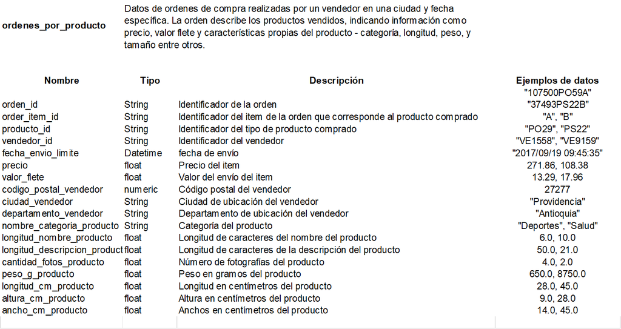

```python
#en primer lugar vamos a validar que cada uno de los atributos tenga el tipo de dato definido en el dicionario de datos.
data_ordenes.dtypes
```

```
orden_id                          object
order_item_id                     object
producto_id                       object
vendedor_id                       object
fecha_envio_limite                object
precio                           float64
valor_flete                      float64
codigo_postal_vendedor             int64
ciudad_vendedor                   object
departamento_vendedor             object
nombre_categoria_producto         object
longitud_nombre_producto         float64
longitud_descripcion_producto    float64
cantidad_fotos_producto          float64
peso_g_producto                  float64
longitud_cm_producto             float64
altura_cm_producto               float64
ancho_cm_producto                float64
dtype: object
```

**Tipos de datos:** observamos que para el caso de la columna "fecha_envio_limite" el tipo de dato no coincide con el descrito en el diccionario de datos. Por lo tanto debemos hacer a comversión del tipo de dato de esta columna a datetime.

```python
#cambiamos el formato de la columna "fecha_envio_limite" a datetime.
data_ordenes['fecha_envio_limite']=pd.to_datetime(data_ordenes['fecha_envio_limite'],format="%d/%m/%Y %H:%M")
#evidenciamos que el cambio se realizó
data_ordenes[["fecha_envio_limite"]].dtypes
```

```
fecha_envio_limite    datetime64[ns]
dtype: object
```

```python
#A simple vista no se observa que hayan problemas de calidad en los datos relacionados con la estandarización a parte del
#tipo de dato de la columna "fecha_envio_limite".Haremos un recuento de las categorías en los atributos categóricos
#para verificar más a fondo si existen o no más problemas en la estandarización.

#seleccionamos solo los atributos categóricos presentes en el dataset.
data_catego=data_ordenes.select_dtypes(include=["object"])
#Revisamos las categorías presentes en cada una de los atributos categóricos.
for i in data_catego.columns:
   print(data_catego[i].value_counts().reset_index(),"\n")
```

```
          orden_id  count
0      107500PO59A      1
1       48085PT66A      1
2       24209PR85B      1
3       36058PB41A      1
4       16627PF73A      1
...            ...    ...
10106   66486PD96A      1
10107    7966PM62A      1
10108   71397PC34A      1
10109  105032PF27A      1
10110   48674PC53A      1

[10111 rows x 2 columns]

```

[output cut: 117 more lines]

**Conclusión de calidad de los datos en la dimensión de completitud:** vemos que el además del problema con el tipo de dato de la columna de fechas de envíos, no se presentan más problemas de estandarización, pues observamos que no hay repetición de categorías por errores en el formato de escritura de estás.

### 2.3 Duplicidad en los datos

### Objetivos

1. Revisar los registros que contienen datos suplicados ya sea de manera parcial o total.
2. Aplicar diversas formas para mejorar la dimensión de duplicidad de los registros de la fuente de datos analizada.

```python
#en primer lugar vamos a revisar si hay presencia de duplicados en el identificador único de la orden de venta.
val_uniq=len(data_ordenes["orden_id"].unique())
val_dupli=data_ordenes.duplicated("orden_id").sum()
print("valores únicos:",val_uniq)
print("Valores duplicados en identificador único:",val_dupli)
```

```
valores únicos: 10111
Valores duplicados en identificador único: 0
```

```python
#vamos a revisar si hay valores duplicados parcialmente en todo el conjunto de datos.
print("Valores duplicados en el data set:",data_ordenes.duplicated().sum())
#Revisamos la proporción de duplicidad en los atributos del dataset
data_ordenes[data_ordenes.duplicated()].count()
```

```
Valores duplicados en el data set: 0
```

```
orden_id                         0
order_item_id                    0
producto_id                      0
vendedor_id                      0
fecha_envio_limite               0
precio                           0
valor_flete                      0
codigo_postal_vendedor           0
ciudad_vendedor                  0
departamento_vendedor            0
nombre_categoria_producto        0
longitud_nombre_producto         0
longitud_descripcion_producto    0
cantidad_fotos_producto          0
peso_g_producto                  0
longitud_cm_producto             0
altura_cm_producto               0
ancho_cm_producto                0
dtype: int64
```

**Conclusión de calidad de los datos en la dimensión de duplicidad:** observamos que no hay presencia de registros duplicados parcialmente o completamente en el conjunto de datos, y lo comprobamos tanto a nivel de identificiador único como a nivel global del set de datos.

### 2.4 Consistencia

### Objetivos

1. Revisar los atributos numéricos y revisar si presentan inconsistencias en su dominio.
2. Aplicar diversas formas para mejorar la dimensión de completitud de la columnas de la fuente de datos analizada.

```python
#Revisamos de manera rápida las variables estadísticas de los atributos numéricos con el fin de determinar si hay inconsistencia.
data_ordenes.describe()
```

|  | fecha_envio_limite | precio | valor_flete | codigo_postal_vendedor | longitud_nombre_producto | longitud_descripcion_producto | cantidad_fotos_producto | peso_g_producto | longitud_cm_producto | altura_cm_producto | ancho_cm_producto |
| --- | --- | --- | --- | --- | --- | --- | --- | --- | --- | --- | --- |
| count | 10111 | 10111.000000 | 10111.000000 | 10111.000000 | 10111.000000 | 10111.000000 | 10111.000000 | 10111.000000 | 10111.000000 | 10111.000000 | 10111.00000 |
| mean | 2018-01-03 05:02:30.406488064 | 119.868468 | 20.062207 | 49995.607457 | 20.070023 | 19.844724 | 20.097616 | 2106.475522 | 30.067352 | 17.911186 | 22.91257 |
| min | 2017-07-13 22:38:00 | 0.010000 | 0.000000 | 5001.000000 | 0.000000 | 0.000000 | 0.000000 | 0.000000 | 0.000000 | 0.000000 | 0.00000 |
| 25% | 2017-10-08 11:40:00 | 34.175000 | 5.760000 | 50001.000000 | 10.000000 | 10.000000 | 10.000000 | 607.000000 | 19.000000 | 9.000000 | 15.00000 |
| 50% | 2018-01-03 06:13:00 | 83.180000 | 13.990000 | 52323.000000 | 20.000000 | 20.000000 | 20.000000 | 1459.000000 | 30.000000 | 17.000000 | 23.00000 |
| 75% | 2018-04-01 03:34:30 | 165.640000 | 27.475000 | 54003.000000 | 30.000000 | 30.000000 | 30.000000 | 2941.000000 | 41.000000 | 26.000000 | 30.00000 |
| max | 2018-06-26 02:19:00 | 1262.940000 | 183.150000 | 99001.000000 | 40.000000 | 40.000000 | 40.000000 | 20661.000000 | 91.000000 | 64.000000 | 72.00000 |
| std | NaN | 119.386311 | 20.111832 | 22461.742889 | 11.719844 | 11.851631 | 11.802373 | 2094.402206 | 15.286299 | 11.359838 | 11.15189 |

**Conclusión de calidad de los datos en la dimensión de consistencia:** podemos observar que los valores mínimos de la mayoría de categorías son 0.0 y para el caso del precio del producto es de 0.010 lo que nos hace preguntarnos si es un error del precio real del producto o si es el precio verdadero; lo mismo sucede con el atributo "codigo_postal_vendedor" en dónde podemos evidenciar que hay códigos postales con un número de dígitos menor a 5. Estas tres situaciones podrían tratarse de datos atípicos por errosres de digitación de la información de registro y deberán ser validadas con el negocio para determinar como poceder con dichos valores en caso de que sean un problema. Mientras tanto, podemos profundizar más en este problema de consistencia de datos numéricos con el objetivo de revisar que tanto se repite esta posible inconsitencia y dar un ´rimer acercamiento a saber si son o no problemas de calidad.

```python
#revisemos con más detalle como se comportan algunas de las columnas de precio, longitud_nombre_producto y codigo_postal_vendedor
data_ordenes[["precio"]].value_counts().reset_index().sort_values(by="precio")
```

|  | precio | count |
| --- | --- | --- |
| 580 | 0.01 | 2 |
| 6713 | 0.03 | 1 |
| 249 | 0.04 | 3 |
| 5987 | 0.05 | 1 |
| 5986 | 0.08 | 1 |
| ... | ... | ... |
| 3487 | 852.29 | 1 |
| 3486 | 884.85 | 1 |
| 3485 | 995.58 | 1 |
| 3484 | 1003.57 | 1 |
| 8378 | 1262.94 | 1 |

8379 rows × 2 columns

**Análisis del atributo precio:** vemos que el precio va aumentando gradualmente desde 0.01 y va incrementando el número de cifras de una manera progresiva; vemos que no es un caso aislado el hecho de que el precio tenga un valor mínimo tan bajo. De igual manera es importante confirmar con el negocio si estos valores son o no erroneos.

```python
#revisamos con más detalle el atributo asociado al código postal del vendedor
data_ordenes[["codigo_postal_vendedor"]].value_counts().reset_index().sort_values(by="codigo_postal_vendedor")
```

|  | codigo_postal_vendedor | count |
| --- | --- | --- |
| 15 | 5001 | 204 |
| 30 | 5002 | 144 |
| 67 | 5004 | 15 |
| 12 | 8001 | 224 |
| 21 | 11001 | 178 |
| ... | ... | ... |
| 29 | 91001 | 145 |
| 25 | 94001 | 158 |
| 45 | 95001 | 92 |
| 18 | 97001 | 187 |
| 64 | 99001 | 22 |

71 rows × 2 columns

```python
#identificamos las ciudades a las que representan dichos códigos postales.
data_codigo=data_ordenes.groupby(["codigo_postal_vendedor","ciudad_vendedor"]).count()[
    "departamento_vendedor"].reset_index(name="Conteo")
data_codigo
```

|  | codigo_postal_vendedor | ciudad_vendedor | Conteo |
| --- | --- | --- | --- |
| 0 | 5001 | Medellin | 204 |
| 1 | 5002 | Abejorral | 144 |
| 2 | 5004 | Abriaqui | 15 |
| 3 | 8001 | Barranquilla | 224 |
| 4 | 11001 | Bogota d.c. | 178 |
| ... | ... | ... | ... |
| 66 | 91001 | Leticia | 145 |
| 67 | 94001 | Inirida | 158 |
| 68 | 95001 | San jose del guaviare | 92 |
| 69 | 97001 | Mitu | 187 |
| 70 | 99001 | Puerto carreño | 22 |

71 rows × 3 columns

```python
#verificamos si hay tantos códigos postales como ciudades en el conjunto de datos, determinando la
#cantidad de valores únicos en cada atrinuto
print("Valores únicos de códigos postales:",data_codigo["codigo_postal_vendedor"].unique().shape)
print("Valores únicos ciudades:",data_codigo["ciudad_vendedor"].unique().shape)
```

```
Valores únicos de códigos postales: (71,)
Valores únicos ciudades: (71,)
```

**Análisis del atributo codigo_postal_vendedor:** podemos observar que hay 4 cados dónde el código postal tiene solo 4 digítos, que no es solo el caso del valor mínimo, por lo cual este caso no es aislado. Para profundizar en este caso comparamos el código postal del vendedor junto con el nombre de la ciudad de este, con el fin de determinar si estos código de 4 dígitos son correctos o es por una omisión de algún dígito al momento del registro. Observamos que la cantidad de valores únicos en cada atributo son iguales, por lo cual se descarta la posibilidad de los códigos con un número de 4 dígitos sean errores de consistencia.

```python
#revisamos con más detalle el atributo asociado a la longitud del nombre del producto
data_ordenes[["longitud_nombre_producto"]].value_counts().reset_index().sort_values(by="longitud_nombre_producto").head(15)
```

|  | longitud_nombre_producto | count |
| --- | --- | --- |
| 40 | 0.0 | 207 |
| 32 | 1.0 | 233 |
| 39 | 2.0 | 224 |
| 17 | 3.0 | 247 |
| 35 | 4.0 | 230 |
| 21 | 5.0 | 245 |
| 22 | 6.0 | 244 |
| 0 | 7.0 | 271 |
| 4 | 8.0 | 266 |
| 5 | 9.0 | 265 |
| 6 | 10.0 | 263 |
| 10 | 11.0 | 260 |
| 25 | 12.0 | 241 |
| 38 | 13.0 | 227 |
| 31 | 14.0 | 236 |

**Análisis del atributo longitud_nombre_producto:** observamos que en total hay 207 productos que aparentemente no tienen un nombre asociado en los registros, un total de 233 que tienen por nombre un solo caracter y 224 que tienen solo 2 caracteres en su nombre. En primer lugar, lo ideal, sería validar con el negocio a ver si esta información se refleja de igual manera en la plataforma digital o si es un error al momento de descargar el conjunto de datos. Del mismo modo se deberán validar los valores que parecen ser atípicos en las otras categorías de las características del producto.

## 3. Análisis estadístico univariado

### Objetivos

1. Determinar cual es el comportamiento estadístico de los atributos numéricos del dataset.
2. Identificar cuales son las categorías de producto más vendidas a nivel nacional y cuales son aquellas que componen el 20% de las ventas principales del negocio digital con el fin de aplicar un descuento el precio de venta sobre estas.
3. Determinar cual el porcentaje de los productos que pesan menos de 1000 g con el fin de aplicar un descuento sobre el valor del flete de estos productos.

```python
#revisamos las principales variables estadísticas del conjunto de datos, tales como media, desviación estandar,
#y percentiles del 25, 50 y 75%.
data_ordenes.describe()
```

|  | fecha_envio_limite | precio | valor_flete | codigo_postal_vendedor | longitud_nombre_producto | longitud_descripcion_producto | cantidad_fotos_producto | peso_g_producto | longitud_cm_producto | altura_cm_producto | ancho_cm_producto |
| --- | --- | --- | --- | --- | --- | --- | --- | --- | --- | --- | --- |
| count | 10111 | 10111.000000 | 10111.000000 | 10111.000000 | 10111.000000 | 10111.000000 | 10111.000000 | 10111.000000 | 10111.000000 | 10111.000000 | 10111.00000 |
| mean | 2018-01-03 05:02:30.406488064 | 119.868468 | 20.062207 | 49995.607457 | 20.070023 | 19.844724 | 20.097616 | 2106.475522 | 30.067352 | 17.911186 | 22.91257 |
| min | 2017-07-13 22:38:00 | 0.010000 | 0.000000 | 5001.000000 | 0.000000 | 0.000000 | 0.000000 | 0.000000 | 0.000000 | 0.000000 | 0.00000 |
| 25% | 2017-10-08 11:40:00 | 34.175000 | 5.760000 | 50001.000000 | 10.000000 | 10.000000 | 10.000000 | 607.000000 | 19.000000 | 9.000000 | 15.00000 |
| 50% | 2018-01-03 06:13:00 | 83.180000 | 13.990000 | 52323.000000 | 20.000000 | 20.000000 | 20.000000 | 1459.000000 | 30.000000 | 17.000000 | 23.00000 |
| 75% | 2018-04-01 03:34:30 | 165.640000 | 27.475000 | 54003.000000 | 30.000000 | 30.000000 | 30.000000 | 2941.000000 | 41.000000 | 26.000000 | 30.00000 |
| max | 2018-06-26 02:19:00 | 1262.940000 | 183.150000 | 99001.000000 | 40.000000 | 40.000000 | 40.000000 | 20661.000000 | 91.000000 | 64.000000 | 72.00000 |
| std | NaN | 119.386311 | 20.111832 | 22461.742889 | 11.719844 | 11.851631 | 11.802373 | 2094.402206 | 15.286299 | 11.359838 | 11.15189 |

A partir de esta primera decripción estadísticas de los datos podemos tener un acercamiento a la forma de distribución de los atributos. Al observar el valor del percentil 50 y el valor máximo del precio de venta, nos damos cuenta que los precios de ventas presentan una asimetría positiva debido a que los datos se concentran en mayor cantidad a la izquierda con un sesgo a la derecha; este también es el caso para el valor del flete, el peso del producto vendido y y las dimensiones del producto. Sin embargo, la concentración de los datos hacia la izquierda es mucho mayor en los atributos de precio, valor del flete y peso del producto.

Para el caso de los atributos relacionados con las características del nombre del producto y la descripción de este, de acuerdo con el valor de su mediana y el valor máximo registrado, se observa que presentan una distribución simétrica.

**Contexto:** desde el negocio están interesados en conocer cuáles son las categorías de productos más vendidad a nivel nacional, del mismo modo que conocer cuales son aquellas categorías que contribuyen al 20% de las ventas principales en el negocio, esto con el fin de diseñar una estrategia de negocio enfocada en dichas categorías en la que se buscará realizar un descuento sobre estas.

```python
#Para conocer cuáles son las categorías de productos más vendidas calcularemos la distribución de frecuencias de este atributo.

#Calculamos la frecuencia absoluta de las distintas categorías.
frec_productos=data_ordenes['nombre_categoria_producto'].value_counts().reset_index()
frec_productos=frec_productos.rename(columns={'count':'fi'})
#Calculamos la fecuencia relativa.
frec_productos['hi %']=frec_productos['fi'].apply(lambda x:((x/frec_productos['fi'].sum())*100).round(1))
#Calculamos ahora la frecuencia absuluta acumulada y relativa acumulada
frec_productos['Fi']=frec_productos['fi'].cumsum() #frecuencia absoluta acumulada
frec_productos['Hi %']=frec_productos['hi %'].cumsum() #frecuencia relativa acumulada
frec_productos
```

|  | nombre_categoria_producto | fi | hi % | Fi | Hi % |
| --- | --- | --- | --- | --- | --- |
| 0 | Tecnología | 542 | 5.4 | 542 | 5.4 |
| 1 | Deportes | 537 | 5.3 | 1079 | 10.7 |
| 2 | Frutas y verduras | 531 | 5.3 | 1610 | 16.0 |
| 3 | Carnicería | 523 | 5.2 | 2133 | 21.2 |
| 4 | Ropa de adultos | 521 | 5.2 | 2654 | 26.4 |
| 5 | Ferretería | 518 | 5.1 | 3172 | 31.5 |
| 6 | Juguetes | 516 | 5.1 | 3688 | 36.6 |
| 7 | Ropa infantil | 511 | 5.1 | 4199 | 41.7 |
| 8 | Electrodomésticos | 509 | 5.0 | 4708 | 46.7 |
| 9 | Dormitorio | 508 | 5.0 | 5216 | 51.7 |
| 10 | Lácteos | 499 | 4.9 | 5715 | 56.6 |
| 11 | Libros | 497 | 4.9 | 6212 | 61.5 |
| 12 | Productos ecoamigables | 497 | 4.9 | 6709 | 66.4 |
| 13 | Mascotas | 495 | 4.9 | 7204 | 71.3 |
| 14 | Tarjetas regalo | 495 | 4.9 | 7699 | 76.2 |
| 15 | Salud | 488 | 4.8 | 8187 | 81.0 |
| 16 | Celulares | 488 | 4.8 | 8675 | 85.8 |
| 17 | Muebles | 486 | 4.8 | 9161 | 90.6 |
| 18 | Licor | 475 | 4.7 | 9636 | 95.3 |
| 19 | Bebés | 475 | 4.7 | 10111 | 100.0 |

Por otro lado, las categorías de Tecnología, Deportes, Frutas y verduras, y Carnicería deberán ser las escogidas para aplicar la estaregia de descuento si se quiere impactar sobre el 20% principal de las ventas.

```python
#vamos a visualizar en un gráfico de pastel como es el comportamiento de las ventas a nivel nacional.
fig = px.pie(frec_productos,values="fi",names="nombre_categoria_producto",
             title="Comportamiento de las ventas a nivel nacional")
fig
```

[interactive chart not shown]

**Contexto:** desde el negocio se ha decido que se quiere aplicar una estrategia de negocio adicional, y para esto desean realizar una campaña de descuento enfocada en el valor del flete de envío de los productos, este descuento en alianza con la empresa de logística, se podrá aplicar solo a aquellos productos que tengan un peso menos a 1000 g.

De acuerdo a lo anterior, la empresa desea conocer cuál es el porcentaje de los productos vendidos al cual se le podrá aplicar dicho descuento y conocer las categorías que se verán impactas.

```python
#a partir de la descripción estadística previa realizada sobre los datos, sabemos que el porcentaje de productos con un peso
#menor o igual a 1000 gr se encuentra entre 25% y 50%. Por ello procedemos a encontrar el percentil en este rango.

#creamos un diccionario para guardar los resultados de percentil y peso del producto.
percentiles={}
rango_min=0.25 #rango de percentil mínimo de búsqueda.
rango_max=0.50 #rango de percentil máximo de búsqueda.
valor_deseado=1000 #peso máximo permitido.

#creamos un ciclo que intere entre el rango propuesto.
for i in np.arange(rango_min,rango_max,0.01):
    if (data_ordenes["peso_g_producto"].quantile(i) - valor_deseado) <= 0:
        #guardamos todos los resultados menores o iguales a 1000 g.
        percentiles[round(i,2)]=round(data_ordenes["peso_g_producto"].quantile(i),0)

#imprimimos el percentil que proporciona el peso de producto más cercano a 1000 g.
print("El porcentaje de productos con un peso menor o igual a 1000 es de",max(percentiles.keys())*100,"%")
```

```
El porcentaje de productos con un peso menor o igual a 1000 es de 37.0 %
```

```python
#Encontremos aquellas categorías que tienen productos con un peso menor a 1000 g.
prod_descuento=data_ordenes.loc[data_ordenes["peso_g_producto"]<=1000,"nombre_categoria_producto"].value_counts().reset_index(name="En descuento")
prod_descuento=pd.merge(prod_descuento,frec_productos[["nombre_categoria_producto","fi"]],on="nombre_categoria_producto",how="inner")
prod_descuento["% de categoría"]=round((prod_descuento["En descuento"]/prod_descuento['fi'])*100,0)
prod_descuento["% de productos"]=round((prod_descuento["En descuento"]/prod_descuento['fi'].sum())*100,1)
prod_descuento
```

|  | nombre_categoria_producto | En descuento | fi | % de categoría | % de productos |
| --- | --- | --- | --- | --- | --- |
| 0 | Ropa de adultos | 210 | 521 | 40.0 | 2.1 |
| 1 | Electrodomésticos | 202 | 509 | 40.0 | 2.0 |
| 2 | Mascotas | 200 | 495 | 40.0 | 2.0 |
| 3 | Carnicería | 199 | 523 | 38.0 | 2.0 |
| 4 | Deportes | 199 | 537 | 37.0 | 2.0 |
| 5 | Libros | 197 | 497 | 40.0 | 1.9 |
| 6 | Tecnología | 195 | 542 | 36.0 | 1.9 |
| 7 | Frutas y verduras | 194 | 531 | 37.0 | 1.9 |
| 8 | Tarjetas regalo | 194 | 495 | 39.0 | 1.9 |
| 9 | Juguetes | 192 | 516 | 37.0 | 1.9 |
| 10 | Dormitorio | 192 | 508 | 38.0 | 1.9 |
| 11 | Muebles | 191 | 486 | 39.0 | 1.9 |
| 12 | Lácteos | 191 | 499 | 38.0 | 1.9 |
| 13 | Productos ecoamigables | 191 | 497 | 38.0 | 1.9 |
| 14 | Ferretería | 190 | 518 | 37.0 | 1.9 |
| 15 | Celulares | 189 | 488 | 39.0 | 1.9 |
| 16 | Salud | 181 | 488 | 37.0 | 1.8 |
| 17 | Ropa infantil | 175 | 511 | 34.0 | 1.7 |
| 18 | Licor | 167 | 475 | 35.0 | 1.7 |
| 19 | Bebés | 164 | 475 | 35.0 | 1.6 |

```python
#visualicemos la cantidad de productos en descuento.
#creamos un dataframe para identificar el total de productos en descuentos y el total de productos que no están en descuento.
proporcion_desc=pd.DataFrame()
proporcion_desc["Estado del producto"]="En descuento","Sin descuento"
proporcion_desc["Cantidad"] = [(prod_descuento["En descuento"].sum()),
                               (-prod_descuento["En descuento"].sum()+prod_descuento['fi'].sum())]
#construimos el gráfico de pastel para visualizar los datos.
fig1 = px.pie(proporcion_desc,values="Cantidad",names="Estado del producto",
             title="Proporción de productos en descuento")
```

```python
#vamos a visualizar en un gráfico de pastel como se distribuye el descuento en productos menores a 1000 g.
fig2 = px.pie(prod_descuento,values="En descuento",names="nombre_categoria_producto",
             title="Constribución de cada categoría a los productos en descuento")
```

```python
#vamos a visualizar en un gráfico de barras como se distribuye el descuento a nivel de categorías.
#creamos colores aleatorias para la figura.
get_colors = lambda n: list(map(lambda i: "#" + "%06x" % random.randint(0, 0xFFFFFF),range(n)))
colores=get_colors(len(prod_descuento))
#creamos la figura con Plotly.
fig3 = px.bar(prod_descuento,x="% de categoría",y="nombre_categoria_producto",color="nombre_categoria_producto",
            color_discrete_sequence=colores,title="Proporción de productos en descuento según su categoría")
#cambiamos el grosor de las barras para que sean más legibles.
for bar in fig3.data:
    bar.width = 0.4
```

```python
#vamos a visualizar en un gráfico de barras como se distribuye el descuento a nivel total de productos constrastado con a nivel
#de categorías.
fig4 = px.bar(prod_descuento,y=["% de productos","% de categoría"],x="nombre_categoria_producto",barmode="group",
            title="Porporción de productos en descuento")
#cambiamos el grosor de las barras para que sean más legibles.
for bar in fig4.data:
    bar.width = 0.4
```

```python
fig.show(),fig1.show(),fig2.show(),fig3.show(),fig4.show()
```

[interactive chart not shown]

```
(None, None, None, None, None)
```

## Conclusión del análisis de negocio

Al describir los datos de manera estadística pudimos y al observar el valor del percentil 50 y el valor máximo del precio de venta, nos dimos cuenta que los precios de venta presentan una asimetría positiva debido a que los datos se concentran en mayor cantidad a la izquierda con un sesgo a la derecha; este también es el caso para el valor del flete, el peso del producto vendido y y las dimensiones del producto. Sin embargo, la concentración de los datos hacia la izquierda es mucho mayor en los atributos de precio, valor del flete y peso del producto.

Para el caso de los atributos relacionados con las características del nombre del producto y la descripción de este, de acuerdo con el valor de su mediana y el valor máximo registrado, se observa que presentan una distribución simétrica.